# Tutorial: Omics data analysis with DataSHIELD

Juan R. Gonzalez

Bioinformatics Research Group in Epidemiolgy (BRGE), Barcelona Insitute for Global Health (ISGlobal)

juanr.gonzalez@isglobal.org

2021-01-27

# 1 Introduction

This tutorial aims to provide examples about how to analyze omics data in DataSHIELD. More detailed information can be found in our bookdown [Orchestrating privacy-protected non-disclosive big data analyses of data from different resources with R and DataSHIELD](https://isglobal-brge.github.io/resource_bookdown/).

# 2 Getting started

This document can be reproduced by installing the following packages

```
install.packages("DSOpal")
devtools::install_github("datashield/dsBaseClient")
devtools::install_github("isglobal-brge/dsOmicsClient")
```

Then the packages are loaded as usual

```r
library(DSOpal)
library(dsBaseClient)
library(dsOmicsClient)
```

We have set up an [Opal demo site](http://opal-demo.obiba.org/) to illustrate how to perform different omic data analyses using DataSHIELD. The DataSHIELD user credentials are

- username: `dsuser`
- password: `password`

We also illustrate how to deal with different *resources* for ’omic data. For this, the Opal server can be accessed with the credentials:

- username: `administrator`
- password: `password`

This tutorial will mainly make use of the resources available at `RSRC` project

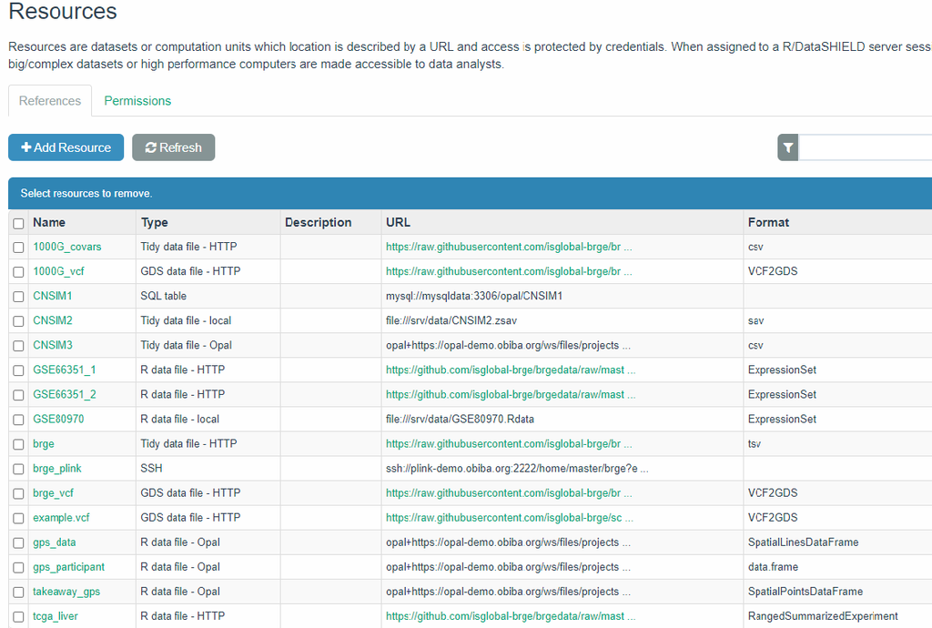

Figure 1: Resources available at Opal demo site of RSRC project

and we will cover how to perform:

> 1. Transcriptomic data analysis
> 2. Epigenomic data analysis
> 3. GWAS

For those who are not familiar with omic data analysis or do not know the state-of-the-art methods, you can read this bookdown on [Omic Data Analysis with R/Bioconductor](https://isglobal-brge.github.io/Master_Bioinformatics/).

# 3 Types of omic data analyses implemented

The Figure 2 describes the different types of ’omic association analyses that can be performed using DataSHIELD client functions implemented in the *dsOmicsClient* package. Basically, data (’omic and phenotypes/covariates) can be stored in different sites (http, ssh, AWS S3, local, …) and are managed with Opal through the *resourcer* package and their extensions implemented in *dsOmics*.

[figure not shown]

Figure 2: Non-disclosive omic data analysis with DataSHIELD and Bioconductor  
The figure illustrates how the `resourcer` package is used to get access to omic data through the Opal servers. Then DataSHIELD is used in the client side to perform non-disclosive data analyses.

The `dsOmicsClient` package allows different types of analyses: pooled and meta-analysis. Both methods are based on fitting different Generalized Linear Models (GLMs) for each feature when assessing association between ’omic data and the phenotype/trait/condition of interest. Of course, non-disclosive ’omic data analysis from a single study can also be performed.

The **pooled approach** (Figure 3) is recommended when the user wants to analyze ’omic data from different sources and obtain results as if the data were located in a single computer. It should be noted that this can be very time consuming when analyzing multiple features since it calls a base function in DataSHIELD (`ds.glm`) repeatedly. It also cannot be recommended when data are not properly harmonized (e.g. gene expression normalized using different methods, GWAS data having different platforms, …). Furthermore when it is necesary to remove unwanted variability (for transcriptomic and epigenomica analysis) or control for population stratification (for GWAS analysis), this approach cannot be used since we need to develop methods to compute surrogate variables (to remove unwanted variability) or PCAs (to to address population stratification) in a non-disclosive way.

The **meta-analysis approach** Figure 4 overcomes the limitations raised when performing pooled analyses. First, the computation issue is addressed by using scalable and fast methods to perform data analysis at whole-genome level at each location The transcriptomic and epigenomic data analyses make use of the widely used *limma* package that uses `ExpressionSet` or `RangedSummarizedExperiment` Bioc infrastructures to deal with ’omic and phenotypic (e.g covariates). The genomic data are analyzed using *GWASTools* and *GENESIS* that are designed to perform quality control (QC) and GWAS using GDS infrastructure.

Next, we describe how both approaches are implemented:

- **Pooled approach:** Figure 3 illustrate how this analysis is performed. This corresponds to generalized linear models (glm) on data from single or multiple sources. It makes use of `ds.glm()` function which is a DataSHIELD function that uses an approach that is mathematically equivalent to placing all individual-level data froma all sources in one central warehouse and analysing those data using the conventional `glm()` function in R. The user can select one (or multiple) features (i.e., genes, transcripts, CpGs, SNPs, …)

[figure not shown]

Figure 3: Non-disclosive omic data analysis with DataSHIELD and Bioconductor  
The figure illustrates how to perform single pooled omic data analysis. The analyses are performed by using a generalized linear model (glm) on data from one or multiple sources. It makes use of `ds.glm()`, a DataSHIELD function, that uses an approach that is mathematically equivalent to placing all individual-level data from all sources in one central warehouse and analysing those data using the conventional `glm()` function in R.

- **Meta-analysis:** Figure 4 illustrate how this analysis is performed. This corresponds to performing a genome-wide analysis at each location using functions that are specifically design for that purpose and that are scalable. Then the results from each location can be meta-analyzed using methods that meta-analyze either effect sizes or p-values.

[figure not shown]

Figure 4: Non-disclosive omic data analysis with DataSHIELD and Bioconductor  
The figure illustrates how to perform anlyses at genome-wide level from one or multiple sources. It runs standard Bioconductor functions at each server independently to speed up the analyses and in the case of having multiple sources, results can be meta-analyzed uning standar R functions.

## 3.1 Differential gene expression (DGE) analysis

Let us illustrate how to perform transcriptomic data analysis using data from [TCGA project](https://www.cancer.gov/about-nci/organization/ccg/research/structural-genomics/tcga). We have uploaded to the opal server a resource called `tcga_liver` whose URL is http://duffel.rail.bio/recount/TCGA/rse_gene_liver.Rdata which is available through the [recount project](https://jhubiostatistics.shinyapps.io/recount/). This resource contains the `RangeSummarizedExperiment` with the RNAseq profiling of liver cancer data from TCGA. Next, we illustrate how a differential expression analysis to compare RNAseq profiling of women vs men (variable `gdc_cases.demographic.gender`). The DGE analysis is normally performed using *limma* package. In that case, as we are analyzing RNA-seq data, `limma + voom` method will be required.

Let us start by creating the connection to the opal server:

```r
builder <- newDSLoginBuilder()
builder$append(server = "study1", url = "https://opal-demo.obiba.org",
               user = "dsuser", password = "password",
               resource = "RSRC.tcga_liver", driver = "OpalDriver")

logindata <- builder$build()

conns <- datashield.login(logins = logindata, assign = TRUE,
                          symbol = "res")
```

Then, let us coerce the resource to a `RangedSummarizedExperiment` which is the type of object that is available in the [recount project](https://jhubiostatistics.shinyapps.io/recount/).

```r
datashield.assign.expr(conns, symbol = "rse",
                       expr = quote(as.resource.object(res)))
ds.class("rse")
```

```
$study1
[1] "RangedSummarizedExperiment"
attr(,"package")
[1] "SummarizedExperiment"
```

The number of features and samples can be inspected by

```r
ds.dim("rse")
```

```
$`dimensions of rse in study1`
[1] 58037   424

$`dimensions of rse in combined studies`
[1] 58037   424
```

And the names of the features using the same function used in the case of analyzing an `ExpressionSet`

```r
name.features <- ds.featureNames("rse")
lapply(name.features, head)
```

```
$study1
[1] "ENSG00000000003.14" "ENSG00000000005.5"  "ENSG00000000419.12" "ENSG00000000457.13"
[5] "ENSG00000000460.16" "ENSG00000000938.12"
```

Also the covariate names can be inspected by

```r
name.vars <- ds.featureData("rse")
lapply(name.vars, head, n=15)
```

```
$study1
 [1] "project"
 [2] "sample"
 [3] "experiment"
 [4] "run"
 [5] "read_count_as_reported_by_sra"
 [6] "reads_downloaded"
 [7] "proportion_of_reads_reported_by_sra_downloaded"
 [8] "paired_end"
 [9] "sra_misreported_paired_end"
[10] "mapped_read_count"
[11] "auc"
[12] "sharq_beta_tissue"
[13] "sharq_beta_cell_type"
[14] "biosample_submission_date"
[15] "biosample_publication_date"
```

We can visualize the levels of the variable having gender information

```r
ds.table("rse$gdc_cases.demographic.gender")
```

```
 Data in all studies were valid

Study 1 :  No errors reported from this study
```

```
$output.list
$output.list$TABLE_rvar.by.study_row.props
                                study
rse$gdc_cases.demographic.gender 1
                          female 1
                          male   1

$output.list$TABLE_rvar.by.study_col.props
                                study
rse$gdc_cases.demographic.gender         1
                          female 0.3372642
                          male   0.6627358

$output.list$TABLE_rvar.by.study_counts
                                study
rse$gdc_cases.demographic.gender   1
                          female 143
                          male   281

$output.list$TABLES.COMBINED_all.sources_proportions
rse$gdc_cases.demographic.gender
female   male
 0.337  0.663

$output.list$TABLES.COMBINED_all.sources_counts
rse$gdc_cases.demographic.gender
female   male
   143    281


$validity.message
[1] "Data in all studies were valid"
```

The differential expression analysis is then performed by:

```r
ans.gender <- ds.limma(model =  ~ gdc_cases.demographic.gender,
                       Set = "rse", type.data = "RNAseq",
                       sva = FALSE)
```

Notice that we have set `type.data='RNAseq'` to consider that our data are counts obtained from a RNA-seq experiment. By indicating so, the differential analysis is performed by using `voom` + `limma` as previously mention.

The top differentially expressed genes can be visualized by:

```r
ans.gender
```

```
$study1
# A tibble: 58,037 x 10
   id                  logFC   CI.L   CI.R AveExpr     t   P.Value adj.P.Val     B     SE
   <chr>               <dbl>  <dbl>  <dbl>   <dbl> <dbl>     <dbl>     <dbl> <dbl>  <dbl>
 1 ENSG00000233070.1   10.8   10.4   11.2  -5.59    55.2 2.89e-196 1.68e-191  418. 0.0763
 2 ENSG00000274655.1  -12.4  -12.8  -11.9  -7.71   -54.8 5.47e-195 1.59e-190  416. 0.460
 3 ENSG00000260197.1   10.1    9.74  10.6  -5.88    48.4 2.45e-175 4.73e-171  373. 0.0601
 4 ENSG00000213318.4   11.4   10.9   11.9  -4.35    45.0 5.62e-164 8.16e-160  345. 0.0649
 5 ENSG00000231535.5    8.98   8.57   9.39 -7.38    42.9 9.49e-157 1.10e-152  334. 0.0886
 6 ENSG00000270641.1  -10.2  -10.7   -9.73  0.0618 -41.7 2.19e-152 2.12e-148  331. 0.118
 7 ENSG00000277577.1  -11.3  -11.9  -10.8  -8.08   -41.1 3.13e-150 2.59e-146  321. 0.127
 8 ENSG00000229807.10 -11.0  -11.6  -10.5  -0.211  -37.6 1.69e-137 1.09e-133  297. 0.0814
 9 ENSG00000278847.1    7.91   7.50   8.32 -7.94    37.9 1.12e-138 8.14e-135  294. 0.0895
10 ENSG00000176728.7   11.1   10.5   11.8  -4.40    36.1 1.46e-131 8.48e-128  277. 0.0923
# ... with 58,027 more rows

attr(,"class")
[1] "dsLimma" "list"
```

We close the DataSHIELD session by:

```r
datashield.logout(conns)
```

## 3.2 Epigenome-wide association analysis (EWAS)

EWAS requires basically the same statistical methods as those used in DGE. It should be notice that the **pooled analysis** we are going to illustrate here can also be performed with transcriptomic data since each study must have different range values. If so, gene expression harmonization should be performed, for instance, by standardizing the data at each study. For EWAS where methylation is measured using beta values (e.g CpG data are in the range 0-1) this is not a problem. In any case, adopting the **meta-analysis** approach could be a safe option.

We have downloaded data from [GEO](https://www.ncbi.nlm.nih.gov/geo/) corresponding to the accesion number GSE66351 which includes DNA methylation profiling (Illumina 450K array) of 190 individuals. Data corresponds to CpGs beta values measured in the superior temporal gyrus and prefrontal cortex brain regions of patients with Alzheimer’s. Data have been downloaded using *GEOquery* package that gets GEO data as `ExpressionSet` objects. Researchers who are not familiar with `ExpressionSet`s can read this Section. Notice that data are encoded as beta-values that ensure data harmonization across studies.

In order to perform omic data analyses, we need first to login and assign resources to DataSHIELD. This can be performed using the `as.resource.object()` function

```r
builder <- DSI::newDSLoginBuilder()
builder$append(server = "study1", url = "https://opal-demo.obiba.org",
               user = "dsuser", password = "password",
               resource = "RSRC.GSE66351_1", driver = "OpalDriver")
builder$append(server = "study2", url = "https://opal-demo.obiba.org",
               user = "dsuser", password = "password",
               resource = "RSRC.GSE66351_2", driver = "OpalDriver")

logindata <- builder$build()

conns <- DSI::datashield.login(logins = logindata, assign = TRUE,
                               symbol = "res")


# Assign to the original R class (e.g ExpressionSet)
datashield.assign.expr(conns, symbol = "methy",
                       expr = quote(as.resource.object(res)))
```

Now, we can see that the resources are actually loaded into the R servers as their original class

```r
ds.class("methy")
```

```
$study1
[1] "ExpressionSet"
attr(,"package")
[1] "Biobase"

$study2
[1] "ExpressionSet"
attr(,"package")
[1] "Biobase"
```

Then, some Bioconductor-type functions can be use to return non-disclosive information of `ExpressionSet`s from each server to the client, using similar functions as those defined in the `dsBaseClient` package. For example, feature names can be returned by

```r
fn <- ds.featureNames("methy")
lapply(fn, head)
```

```
$study1
[1] "cg00000029" "cg00000108" "cg00000109" "cg00000165" "cg00000236" "cg00000289"

$study2
[1] "cg00000029" "cg00000108" "cg00000109" "cg00000165" "cg00000236" "cg00000289"
```

Experimental phenotypes variables can be obtained by

```r
ds.varLabels("methy")
```

```
$study1
 [1] "title"                   "geo_accession"           "status"
 [4] "submission_date"         "last_update_date"        "type"
 [7] "channel_count"           "source_name_ch1"         "organism_ch1"
[10] "characteristics_ch1"     "characteristics_ch1.1"   "characteristics_ch1.2"
[13] "characteristics_ch1.3"   "characteristics_ch1.4"   "characteristics_ch1.5"
[16] "characteristics_ch1.6"   "characteristics_ch1.7"   "characteristics_ch1.8"
[19] "molecule_ch1"            "extract_protocol_ch1"    "label_ch1"
[22] "label_protocol_ch1"      "taxid_ch1"               "hyb_protocol"
[25] "scan_protocol"           "description"             "data_processing"
[28] "platform_id"             "contact_name"            "contact_email"
[31] "contact_phone"           "contact_laboratory"      "contact_institute"
[34] "contact_address"         "contact_city"            "contact_zip/postal_code"
[37] "contact_country"         "supplementary_file"      "supplementary_file.1"
[40] "data_row_count"          "age"                     "braak_stage"
```

[output cut: 25 more lines]

### 3.2.1 Single CpG analysis

Once the methylation data have been loaded into the opal server, we can perform different type of analyses using functions from the `dsOmicsClient` package. Let us start by illustrating how to analyze a single CpG from two studies by using an approach that is mathematically equivalent to placing all individual-level.

```r
ans <- ds.lmFeature(feature = "cg07363416",
                    model = ~ diagnosis + Sex,
                    Set = "methy",
                    datasources = conns)
ans
```

```
             Estimate Std. Error   p-value
cg07363416 0.03459886 0.02504291 0.1670998
attr(,"class")
[1] "dsLmFeature" "matrix"      "array"
```

### 3.2.2 Multiple CpG analysis

The same analysis can be performed for all features (e.g. CpGs) just avoiding the `feature` argument. This process can be parallelized using `mclapply` function from the `multicore` package.

```r
ans <- ds.lmFeature(model = ~ diagnosis + Sex,
                    Set = "methy",
                    datasources = conns,
                    mc.cores = 20)
```

This method corresponds to the **pooled analysis** approach and can be very time consiming since the function repeatedly calls the DataSHIELD function `ds.glm()`. We can adopt another strategy that is to run a glm of each feature independently at each study using `limma` package (which is really fast) and then combine the results (i.e. **meta-analysis** approach).

```r
ans.limma <- ds.limma(model = ~ diagnosis + Sex,
                      Set = "methy",
                      datasources = conns)
```

Then, we can visualize the top genes at each study (i.e server) by

```r
lapply(ans.limma, head)
```

```
$study1
# A tibble: 6 x 10
  id           logFC    CI.L    CI.R AveExpr     t       P.Value adj.P.Val     B      SE
  <chr>        <dbl>   <dbl>   <dbl>   <dbl> <dbl>         <dbl>     <dbl> <dbl>   <dbl>
1 cg13138089 -0.147  -0.191  -0.103    0.380 -6.62 0.00000000190  0.000466 10.6  0.0122
2 cg23859635 -0.0569 -0.0741 -0.0397   0.200 -6.58 0.00000000232  0.000466 10.4  0.00520
3 cg13772815 -0.0820 -0.107  -0.0570   0.437 -6.50 0.00000000327  0.000466 10.0  0.0135
4 cg12706938 -0.0519 -0.0678 -0.0359   0.145 -6.45 0.00000000425  0.000466  9.76 0.00872
5 cg24724506 -0.0452 -0.0593 -0.0312   0.139 -6.39 0.00000000547  0.000466  9.51 0.00775
6 cg02812891 -0.125  -0.165  -0.0860   0.247 -6.33 0.00000000731  0.000466  9.23 0.0163

$study2
# A tibble: 6 x 10
  id           logFC    CI.L    CI.R AveExpr     t      P.Value adj.P.Val     B      SE
  <chr>        <dbl>   <dbl>   <dbl>   <dbl> <dbl>        <dbl>     <dbl> <dbl>   <dbl>
1 cg04046629 -0.101  -0.135  -0.0669  0.345  -5.91 0.0000000621    0.0172  7.18 0.0128
2 cg07664323 -0.0431 -0.0577 -0.0284  0.776  -5.85 0.0000000822    0.0172  6.90 0.00390
3 cg27098804 -0.0688 -0.0924 -0.0452  0.277  -5.79 0.000000107     0.0172  6.64 0.0147
4 cg08933615 -0.0461 -0.0627 -0.0296  0.166  -5.55 0.000000298     0.0360  5.64 0.00791
5 cg18349298 -0.0491 -0.0671 -0.0311  0.157  -5.42 0.000000507     0.0489  5.12 0.00848
6 cg02182795 -0.0199 -0.0272 -0.0125  0.0947 -5.36 0.000000670     0.0538  4.84 0.0155
```

The annotation can be added by using the argument `annotCols`. It should be a vector with the columns of the annotation available in the `ExpressionSet` or `RangedSummarizedExperiment` that want to be showed. The columns of the annotation can be obtained by

```r
ds.fvarLabels("methy")
```

[output not shown]

[output cut: 25 more lines]

Then we can run the analysis and obtain the output with the chromosome and gene symbol by:

```r
ans.limma.annot <- ds.limma(model = ~ diagnosis + Sex,
                            Set = "methy",
                            annotCols = c("CHR", "UCSC_RefGene_Name"),
                            datasources = conns)
```

```r
lapply(ans.limma.annot, head)
```

```
$study1
# A tibble: 6 x 12
  id    CHR   UCSC_RefGene_Na~   logFC    CI.L    CI.R AveExpr     t P.Value adj.P.Val     B      SE
  <chr> <chr> <chr>              <dbl>   <dbl>   <dbl>   <dbl> <dbl>   <dbl>     <dbl> <dbl>   <dbl>
1 cg13~ 2     "ECEL1P2"        -0.147  -0.191  -0.103    0.380 -6.62 1.90e-9  0.000466 10.6  0.0122
2 cg23~ 2     "MTA3"           -0.0569 -0.0741 -0.0397   0.200 -6.58 2.32e-9  0.000466 10.4  0.00520
3 cg13~ 17    ""               -0.0820 -0.107  -0.0570   0.437 -6.50 3.27e-9  0.000466 10.0  0.0135
4 cg12~ 19    "MEX3D"          -0.0519 -0.0678 -0.0359   0.145 -6.45 4.25e-9  0.000466  9.76 0.00872
5 cg24~ 19    "ISOC2;ISOC2;IS~ -0.0452 -0.0593 -0.0312   0.139 -6.39 5.47e-9  0.000466  9.51 0.00775
6 cg02~ 2     "ECEL1P2"        -0.125  -0.165  -0.0860   0.247 -6.33 7.31e-9  0.000466  9.23 0.0163

$study2
# A tibble: 6 x 12
  id    CHR   UCSC_RefGene_Na~   logFC    CI.L    CI.R AveExpr     t P.Value adj.P.Val     B      SE
  <chr> <chr> <chr>              <dbl>   <dbl>   <dbl>   <dbl> <dbl>   <dbl>     <dbl> <dbl>   <dbl>
1 cg04~ 11    "CD6"            -0.101  -0.135  -0.0669  0.345  -5.91 6.21e-8    0.0172  7.18 0.0128
2 cg07~ 6     "MUC21"          -0.0431 -0.0577 -0.0284  0.776  -5.85 8.22e-8    0.0172  6.90 0.00390
3 cg27~ 11    "CD6"            -0.0688 -0.0924 -0.0452  0.277  -5.79 1.07e-7    0.0172  6.64 0.0147
4 cg08~ 1     ""               -0.0461 -0.0627 -0.0296  0.166  -5.55 2.98e-7    0.0360  5.64 0.00791
5 cg18~ 3     "RARRES1;RARRES~ -0.0491 -0.0671 -0.0311  0.157  -5.42 5.07e-7    0.0489  5.12 0.00848
6 cg02~ 8     ""               -0.0199 -0.0272 -0.0125  0.0947 -5.36 6.70e-7    0.0538  4.84 0.0155
```

Then, the last step is to meta-analyze the results. Different methods can be used to this end. We have implemented a method that meta-analyze the p-pvalues of each study as follows:

```r
ans.meta <- metaPvalues(ans.limma)
ans.meta
```

```
# A tibble: 481,868 x 4
   id                study1      study2   p.meta
   <chr>              <dbl>       <dbl>    <dbl>
 1 cg13138089 0.00000000190 0.00000763  4.78e-13
 2 cg25317941 0.0000000179  0.00000196  1.12e-12
 3 cg02812891 0.00000000731 0.00000707  1.63e-12
 4 cg12706938 0.00000000425 0.0000161   2.14e-12
 5 cg16026647 0.000000101   0.000000797 2.51e-12
 6 cg12695465 0.00000000985 0.0000144   4.33e-12
 7 cg21171625 0.000000146   0.00000225  9.78e-12
 8 cg13772815 0.00000000327 0.000122    1.18e-11
 9 cg00228891 0.000000166   0.00000283  1.38e-11
10 cg21488617 0.0000000186  0.0000299   1.62e-11
# ... with 481,858 more rows
```

We can verify that the results are pretty similar to those obtained using pooled analyses. Here we compute the association for two of the top-CpGs:

```r
res1 <- ds.lmFeature(feature = "cg13138089",
                     model = ~ diagnosis + Sex,
                     Set = "methy",
                     datasources = conns)
res1
```

```
             Estimate Std. Error      p-value
cg13138089 -0.1373348 0.01712405 1.057482e-15
attr(,"class")
[1] "dsLmFeature" "matrix"      "array"
```

```r
res2 <- ds.lmFeature(feature = "cg13772815",
                     model = ~ diagnosis + Sex,
                     Set = "methy",
                     datasources = conns)
res2
```

```
              Estimate  Std. Error      p-value
cg13772815 -0.06786137 0.009128915 1.056225e-13
attr(,"class")
[1] "dsLmFeature" "matrix"      "array"
```

We can create a QQ-plot by using the function `qqplot` available in our package.

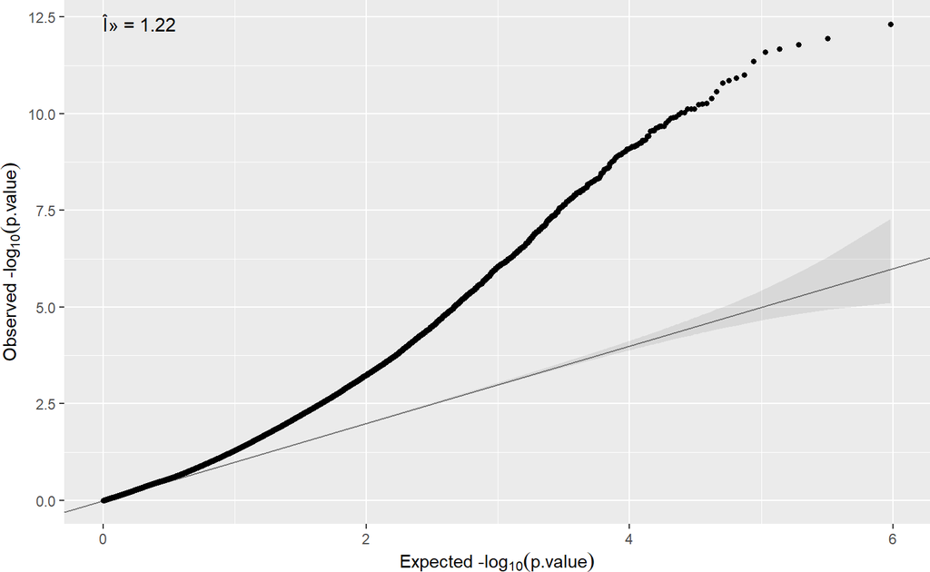

```r
qqplot(ans.meta$p.meta)
```

### 3.2.3 Adjusting for Surrogate Variables

The vast majority of omic studies require to control for unwanted variability. The surrogate variable analysis (SVA) can address this issue by estimating some hidden covariates that capture differences across individuals due to some artifacts such as batch effects or sample quality sam among others. The method is implemented in *SVA* package.

Performing this type of analysis using the `ds.lmFeature` function is not allowed since estimating SVA would require to implement a non-disclosive method that computes SVA from the different servers. This will be a future topic of the `dsOmicsClient`. NOTE that, estimating SVA separately at each server would not be a good idea since the aim of SVA is to capture differences mainly due to experimental issues among ALL individuals. What we can do instead is to use the `ds.limma` function to perform the analyses adjusted for SVA at each study.

```r
ans.sva <- ds.limma(model = ~ diagnosis + Sex,
                    Set = "methy",
                    sva = TRUE, annotCols = c("CHR", "UCSC_RefGene_Name"))
ans.sva
```

```
$study1
# A tibble: 481,868 x 12
   id    CHR   UCSC_RefGene_Na~   logFC    CI.L    CI.R AveExpr     t P.Value adj.P.Val     B
   <chr> <chr> <chr>              <dbl>   <dbl>   <dbl>   <dbl> <dbl>   <dbl>     <dbl> <dbl>
 1 cg10~ 19    "GNG7"           -0.0547 -0.0721 -0.0373   0.338 -6.25 1.31e-8   0.00591  8.51
 2 cg13~ 17    ""               -0.0569 -0.0757 -0.0381   0.437 -6.00 3.91e-8   0.00591  7.43
 3 cg11~ 19    "PODNL1;PODNL1;~  0.0334  0.0223  0.0445   0.568  5.97 4.53e-8   0.00591  7.29
 4 cg27~ 17    "SLC47A2;SLC47A~  0.0274  0.0182  0.0365   0.548  5.95 4.91e-8   0.00591  7.21
 5 cg21~ 6     ""               -0.0453 -0.0609 -0.0297   0.799 -5.78 1.05e-7   0.00666  6.46
 6 cg23~ 2     "MTA3"           -0.0327 -0.0440 -0.0215   0.200 -5.77 1.09e-7   0.00666  6.42
 7 cg10~ 16    "SALL1;SALL1"     0.0366  0.0240  0.0492   0.137  5.77 1.10e-7   0.00666  6.42
 8 cg24~ 1     ""                0.0317  0.0208  0.0427   0.821  5.76 1.11e-7   0.00666  6.41
 9 cg13~ 9     ""               -0.0326 -0.0440 -0.0213   0.367 -5.72 1.32e-7   0.00705  6.24
10 cg13~ 2     "ECEL1P2"        -0.106  -0.144  -0.0686   0.380 -5.61 2.15e-7   0.00835  5.76
# ... with 481,858 more rows, and 1 more variable: SE <dbl>

$study2
# A tibble: 481,868 x 12
   id    CHR   UCSC_RefGene_Na~   logFC    CI.L    CI.R AveExpr     t P.Value adj.P.Val     B
   <chr> <chr> <chr>              <dbl>   <dbl>   <dbl>   <dbl> <dbl>   <dbl>     <dbl> <dbl>
 1 cg16~ 12    "LRP1"           -0.0418 -0.0548 -0.0289   0.388 -6.42 7.82e-9   0.00374  9.05
 2 cg25~ 1     ""               -0.0664 -0.0874 -0.0453   0.569 -6.27 1.55e-8   0.00374  8.37
 3 cg12~ 11    "NRXN2;NRXN2"    -0.0273 -0.0367 -0.0179   0.728 -5.81 1.13e-7   0.0149   6.42
 4 cg07~ 3     ""               -0.0393 -0.0529 -0.0258   0.160 -5.78 1.24e-7   0.0149   6.32
 5 cg07~ 6     "MUC21"          -0.0427 -0.0579 -0.0276   0.776 -5.61 2.63e-7   0.0163   5.59
 6 cg00~ 1     "CR1L"           -0.0568 -0.0771 -0.0365   0.350 -5.56 3.18e-7   0.0163   5.40
 7 cg11~ 12    "CNTN1;CNTN1"    -0.0443 -0.0601 -0.0284   0.152 -5.56 3.18e-7   0.0163   5.40
 8 cg03~ 7     "PGAM2;PGAM2"    -0.0442 -0.0600 -0.0283   0.211 -5.56 3.26e-7   0.0163   5.38
 9 cg07~ 1     "KCNAB2;KCNAB2"   0.0611  0.0392  0.0831   0.659  5.54 3.47e-7   0.0163   5.31
10 cg25~ 17    "WNK4"           -0.0392 -0.0533 -0.0251   0.512 -5.52 3.70e-7   0.0163   5.25
# ... with 481,858 more rows, and 1 more variable: SE <dbl>

attr(,"class")
[1] "dsLimma" "list"
```

Then, data can be combined meta-anlyzed as follows:

```r
ans.meta.sv <- metaPvalues(ans.sva)
ans.meta.sv
```

```
# A tibble: 481,868 x 4
   id               study1      study2   p.meta
   <chr>             <dbl>       <dbl>    <dbl>
 1 cg00228891 0.00000397   0.000000318 3.58e-11
 2 cg01301319 0.00000609   0.00000123  2.00e-10
 3 cg22962123 0.00000106   0.00000767  2.17e-10
 4 cg24302412 0.0000139    0.000000762 2.77e-10
 5 cg02812891 0.000000408  0.0000327   3.47e-10
 6 cg23859635 0.000000109  0.000190    5.29e-10
 7 cg13138089 0.000000215  0.000105    5.74e-10
 8 cg24938077 0.0000125    0.00000254  8.02e-10
 9 cg13772815 0.0000000391 0.00132     1.27e- 9
10 cg21212881 0.000000340  0.000248    2.04e- 9
# ... with 481,858 more rows
```

The DataSHIELD session must by closed by:

```r
datashield.logout(conns)
```

## 3.3 Exercise 1

> He have collected information on methylation data (200 more variable CpGs) in order to compare methylation patterns in inner-city children with persistent atopic asthma (n=97) versus healthy controls (n=97). The authors used DNA from peripheral blood mononuclear cells (PBMCs) from inner city children aged 6-12 years with persistent atopic asthma children and healthy controls. Comparing asthmatics (N=97) to controls (N=97). Original data are available at GEO under the accession number GSE40732. The `ExpressionSet` with 194 samples is available at:
> - https://github.com/isglobal-brge/brgedata/raw/master/data/GSE40732.Rdata

> This data can be use later to check that DataSHIELD (using `dsOmics`) is providing the same results as if we had the whole data in a single computer

> We have split this data set in two and have created two resources in the Opal demo site (https://opal-demo.obiba.org/) that can be access through DataSHIELD using the credentials:

> ```
> - user: dsuser
> - password: password
> ```

> The two resources are in the project called `workshop` and their names are `GSE40732_1` and `GSE40732_2`
> 1. Login the connection to the two resources to DataSHIELD.
> 2. Assign the resources to an R object called ‘methy’.
> 3. Use `ds.nFeatures ()` and `ds.nSamples ()` functions to verify that the loaded objects are having the proper dimensions.
> 4. Get the names of the variables available in the sample metadata (use `ds.varLabels ()`).
> 5. Get the distribution of samples in the variable `asthma` (cases/controls).
> 6. Perform an EWAS considering `asthma` as the condition (e.g. grouping variable).
> 7. Do a simple meta-analysis using `metaPvalues ()` function.

## 3.4 Genome-wide association analyses (GWAS)

Genomic data can be stored in different formats. [VCF](https://www.internationalgenome.org/wiki/Analysis/vcf4.0/) and [PLINK](http://zzz.bwh.harvard.edu/plink/) files are commonly used in genetic epidemiology studies. We have a GWAS example available at [BRGE data repository](https://github.com/isglobal-brge/brgedata) that aims to find SNPs associated with asthma. We have data stored in VCF (brge.vcf) with several covariates and phenotypes available in the file brge.txt (gender, age, obesity, smoking, country and asthma status). The same data is also available in PLINK format (brge.bed, brge.bim, brge.fam) with covariates in the file brge.phe.

Here we illustrate how to perform GWAS using R and Bioconductor packages or PLINK shell command line.

### 3.4.1 GWAS with Bioconductor

We have created a resource having the VCF file of our study on asthma as previously described. The name of the resource is `brge_vcf` the phenotypes are available in another resource called `brge` that is a .txt file. The GWAS analysis is then perform as follows

We first start by preparing login data

```r
builder <- newDSLoginBuilder()
builder$append(server = "study1", url = "https://opal-demo.obiba.org",
               user = "dsuser", password = "password",
               resource = "RSRC.brge_vcf", driver = "OpalDriver")
logindata <- builder$build()

conns <- datashield.login(logins = logindata, assign = TRUE,
                          symbol = "res")
```

```r
datashield.assign.resource(conns, symbol = "vcf.res",
                           resource = list(study1 = "RSRC.brge_vcf"))
datashield.assign.expr(conns, symbol = "gds",
                       expr = quote(as.resource.object(vcf.res)))


datashield.assign.resource(conns, symbol = "covars.res",
                           resource = list(study1 = "RSRC.brge"))
datashield.assign.expr(conns, symbol = "covars",
                       expr = quote(as.resource.data.frame(covars.res)))
```

These are the objects available in the Opal server

```r
ds.ls()
```

```
$study1
$study1$environment.searched
[1] "R_GlobalEnv"

$study1$objects.found
[1] "covars"     "covars.res" "gds"        "res"        "vcf.res"
```

We can use *dsBaseClient* functions to inspect the variables that are in the `covars` data.frame. The variables are

```r
ds.colnames("covars")
```

```
$study1
[1] "scanID"  "gender"  "obese"   "age"     "smoke"   "country" "asthma"
```

The `asthma` variable has this number of individuals at each level (0: controls, 1: cases)

```r
ds.table("covars$asthma")
```

```
 Data in all studies were valid

Study 1 :  No errors reported from this study
```

```
$output.list
$output.list$TABLE_rvar.by.study_row.props
             study
covars$asthma 1
            0 1
            1 1

$output.list$TABLE_rvar.by.study_col.props
             study
covars$asthma         1
            0 0.6864187
            1 0.3135813

$output.list$TABLE_rvar.by.study_counts
             study
covars$asthma    1
            0 1587
            1  725

$output.list$TABLES.COMBINED_all.sources_proportions
covars$asthma
    0     1
0.686 0.314

$output.list$TABLES.COMBINED_all.sources_counts
covars$asthma
   0    1
1587  725


$validity.message
[1] "Data in all studies were valid"
```

There may be interest in only studying certain genes, for that matter, the loaded VCF resource can be subsetting as follows

```r
genes <- c("A1BG","A2MP1")
ds.getSNPSbyGen("gds", genes)
```

The previous code will over-write the VCF with the SNPs corresponding to the selected genes, if the intention is to perform studies with both the complete VCF and a subsetted one, the argument `name` can be used to create a new object on the server with the subsetted VCF, preserving the complete one.

```r
genes <- c("A1BG","A2MP1")
ds.getSNPSbyGen("gds", genes = genes, name = "subset.vcf")
```

Then, an object of class `GenotypeData` must be created at the server side to perform genetic data analyses. This is a container defined in the *GWASTools* package for storing genotype and phenotypic data from genetic association studies. By doing that we will also verify whether individuals in the GDS (e.g VCF) and covariates files have the same individuals and are in the same order. This can be performed by

```r
ds.GenotypeData(x='gds', covars = 'covars', columnId = 1, newobj.name = 'gds.Data')
```

Before performing the association analyses, quality control (QC) can be performed to the loaded data. Three methodologies are available; 1) Principal Component Analysis (PCA) of the genomic data, 2) Hardy-Weinberg Equilibrium (HWE) testing and 3) Allelic frequency estimates. The QC methods 2 and 3 have as inputs a *GenotypeData* object, created with a covariates file that has a gender column; while method 1 has as input a *VCF*.

To perform the PCA, a pruning functionality is built inside so that redundant SNPs are discarted (there is an extra argument `ld.threshold` which controls the pruning, more information about it at the [SNPRelate documentation](https://rdrr.io/bioc/SNPRelate/man/snpgdsLDpruning.html)), speeding up the execution time

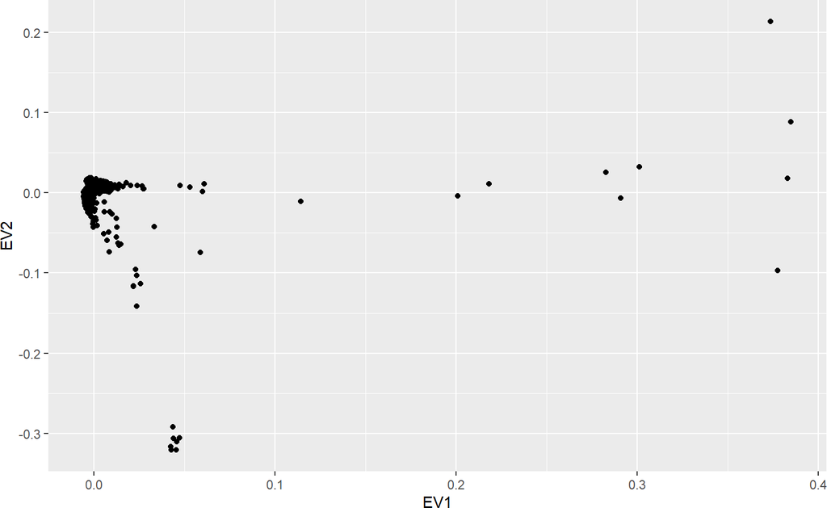

```r
ds.PCASNPS("gds", prune = TRUE)
```

To perform QC methodologies 2 and 3, the name of the gender column as well as the keys to describe male or female have to be provided. Remember that we can visualize the names of the variables from our data by executing `ds.colnames("covars")`. In our case, this variable is called “gender”, and the levels of this variable are 1 for male and 2 for female as we can see here (NOTE: we cannot use `ds.levels` since gender variable is not a factor):

```r
ds.table1D("covars$gender")$counts
```

```
      covars$gender
1              1215
2              1097
Total          2312
```

The HWE test can be performed to selected chromosomes using the argument `chromosomes`, only the autosomes can be selected when performing a HWE test, the encoding of the autosomes can be fetched with

```r
ds.getChromosomeNames("gds.Data")$autosomes
```

Therefore, HWE can be performed by:

```r
ds.exactHWE("gds.Data", sexcol = "gender", male = "1", female = "2", chromosome = "22")
```

```
$study1
# A tibble: 1,581 x 9
   snpID chr   nAA   nAB   nBB   MAF               minor.allele f                 pval
   <int> <chr> <chr> <chr> <chr> <chr>             <chr>        <chr>             <chr>
 1 95140 22    531   1082  640   0.475810031069685 A            0.03724945341034~ 0.0762378420092437
 2 95141 22    580   1092  590   0.497789566755084 A            0.03446388812448~ 0.101115839682148
 3 95142 22    0     333   1951  0.07289842381786~ A            -0.0786304604486~ 3.29321452000707e~
 4 95143 22    0     225   2080  0.04880694143167~ A            -0.0513112884834~ 0.005713534221738~
 5 95144 22    176   831   1249  0.262189716312057 A            0.04792409337548~ 0.025554465064758
 6 95145 22    249   1003  1055  0.32531426094495  A            0.00958157673233~ 0.635607524466151
 7 95146 22    55    516   1738  0.135556517973149 A            0.04646033280618~ 0.0325126363699498
 8 95147 22    203   929   1164  0.290722996515679 A            0.01888804177461~ 0.362631409282596
 9 95148 22    291   1035  985   0.349848550411077 A            0.01549983175844~ 0.464409674690009
10 95149 22    11    276   2013  0.06478260869565~ A            0.00966929694008~ 0.604847402951204
# ... with 1,571 more rows

attr(,"class")
[1] "dsexactHWE" "list"
```

Similarly, allele frequencies estimates can be estimated by:

```r
ds.alleleFrequency("gds.Data", sexcol = "gender", male = "1", female = "2")
```

```
$study1
# A tibble: 99,289 x 7
          M       F      all   n.M   n.F     n      MAF
      <dbl>   <dbl>    <dbl> <dbl> <dbl> <dbl>    <dbl>
 1 0.015    0.0147  0.0149    1200  1086  2286 0.0149
 2 0.000837 0.00276 0.00175   1195  1087  2282 0.00175
 3 0.00330  0.00548 0.00433   1212  1095  2307 0.00433
 4 0.0124   0.00868 0.0106    1213  1095  2308 0.0106
 5 0.00165  0       0.000866  1214  1095  2309 0.000866
 6 0.0712   0.0754  0.0732    1208  1094  2302 0.0732
 7 0.00660  0.00913 0.00780   1213  1095  2308 0.00780
 8 0.00248  0.00274 0.00261   1209  1093  2302 0.00261
 9 0.182    0.181   0.181     1188  1071  2259 0.181
10 0.00165  0       0.000868  1210  1094  2304 0.000868
# ... with 99,279 more rows

attr(,"class")
[1] "dsalleleFrequency" "list"
```

In the future, more functions will be created to perform quality control (QC) for both, SNPs and inviduals.

Association analysis for a given SNP is performed by simply

```r
ds.glmSNP(snps.fit = "rs11247693", model = asthma ~ gender + age, genoData='gds.Data')
```

```
             Estimate Std. Error   p-value
rs11247693 -0.1543215  0.2309585 0.5040196
attr(,"class")
[1] "dsGlmSNP" "matrix"   "array"
```

The analysis of all available SNPs is performed when the argument `snps.fit` is missing. The function performs the analysis of the selected SNPs in a single repository or in multiple repositories as performing pooled analyses (it uses `ds.glm` DataSHIELD function). As in the case of transcriptomic data, analyzing all the SNPs in the genome (e.g GWAS) will be high time-consuming. We can adopt a similar approach as the one adopted using the *limma* at each server. That is, we run GWAS at each repository using specific and scalable packages available in R/Bioc. In that case we use the *GWASTools* and *GENESIS* packages. The complete pipeline is implemented in this function

```r
ans.bioC <- ds.GWAS('gds.Data', model=asthma~age+country)
```

This close the DataSHIELD session

```r
datashield.logout(conns)
```

### 3.4.2 GWAS with PLINK

Here we illustrate how to perform the same GWAS analyses on the asthma using PLINK secure shell commands. This can be performed thanks to the posibility of having ssh resources as described here.

It is worth to notice that this workflow and the new R functions implemented in *dsOmicsClient* could be used as a guideline to carry out similar analyses using existing analysis tools in genomics such as IMPUTE, SAMtools or BEDtools among many others.

We start by assigning login resources

```r
  library(DSOpal)
  library(dsBaseClient)
  library(dsOmicsClient)
  builder <- newDSLoginBuilder()
  builder$append(server = "study1", url = "https://opal-demo.obiba.org",
                 user = "dsuser", password = "password",
                 resource = "RSRC.brge_plink", driver = "OpalDriver")
  logindata <- builder$build()
```

Then we assign the resource to a symbol (i.e. R object) called `client` which is a ssh resource

```r
  conns <- datashield.login(logins = logindata, assign = TRUE,
                            symbol = "client")
  ds.class("client")
```

```
$study1
[1] "SshResourceClient"     "CommandResourceClient" "ResourceClient"        "R6"
```

Now, we are ready to run any PLINK command from the client site. Notice that in this case we want to assess association between the genotype data in bed format and use as phenotype the variable ‘asthma’ that is in the file ‘brge.phe’ in the 6th column. The sentence in a PLINK command would be (NOTE: we avoid –out to indicate the output file since the file will be available in R as a tibble).

```
  plink --bfile brge --logistic --pheno brge.phe --mpheno 6 --covar brge.phe --covar-name gender,age
```

The arguments must be encapsulated in a single character without the command ‘plink’

```r
  plink.arguments <- "--bfile brge --logistic --pheno brge.phe --mpheno 6 --covar brge.phe --covar-name gender,age"
```

the analyses are then performed by

```r
  ans.plink <- ds.PLINK("client", plink.arguments)
```

The object `ans.plink` contains the PLINK results at each server as well as the outuput provided by PLINK

```r
  lapply(ans.plink, names)
```

```
$study1
[1] "results"   "plink.out"
```

```r
  head(ans.plink$study1$results)
```

```
# A tibble: 6 x 9
    CHR SNP           BP A1    TEST   NMISS    OR   STAT        P
  <dbl> <chr>      <dbl> <chr> <chr>  <dbl> <dbl>  <dbl>    <dbl>
1     0 MitoC3993T  3993 T     ADD     2286 0.752 -1.33  0.182
2     0 MitoC3993T  3993 T     gender  2286 0.742 -3.27  0.00107
3     0 MitoC3993T  3993 T     age     2286 1.00   0.565 0.572
4     0 MitoG4821A  4821 A     ADD     2282 2.68   1.71  0.0879
5     0 MitoG4821A  4821 A     gender  2282 0.740 -3.31  0.000940
6     0 MitoG4821A  4821 A     age     2282 1.00   0.465 0.642
```

```r
  ans.plink$study$plink.out
```

```
$status
[1] 0

$output
 [1] ""
 [2] "@----------------------------------------------------------@"
 [3] "|        PLINK!       |     v1.07      |   10/Aug/2009     |"
 [4] "|----------------------------------------------------------|"
 [5] "|  (C) 2009 Shaun Purcell, GNU General Public License, v2  |"
 [6] "|----------------------------------------------------------|"
 [7] "|  For documentation, citation & bug-report instructions:  |"
 [8] "|        http://pngu.mgh.harvard.edu/purcell/plink/        |"
 [9] "@----------------------------------------------------------@"
[10] ""
[11] "Skipping web check... [ --noweb ] "
```

[output cut: 59 more lines]

We can compare the p-values obtained using PLINK with Bioconductor-based packages for the top-10 SNPs as follows:

```r
  library(tidyverse)
  # get SNP p.values (additive model - ADD)
  res.plink <- ans.plink$study1$results %>% filter(TEST=="ADD") %>%
    arrange(P)
  # compare top-10 with Biocoductor's results
  snps <- res.plink$SNP[1:10]
  plink <- res.plink %>% filter(SNP%in%snps) %>% dplyr::select(SNP, P)
  bioC <- ans.bioC$study1 %>% filter(rs%in%snps) %>% dplyr::select(rs, Score.pval)
  left_join(plink, bioC, by=c("SNP" = "rs"))
```

```
# A tibble: 10 x 3
   SNP                 P  Score.pval
   <chr>           <dbl>       <dbl>
 1 rs2267914  0.00000151 0.000000809
 2 rs6097326  0.00000424 0.00000642
 3 rs7153     0.00000440 0.00000508
 4 rs3732410  0.00000817 0.00000940
 5 rs7995146  0.0000170  0.0000195
 6 rs6495788  0.0000213  0.0000278
 7 rs1602679  0.0000268  0.0000264
 8 rs11055608 0.0000270  0.0000161
 9 rs7098143  0.0000313  0.0000214
10 rs7676164  0.0000543  0.0000537
```

As expected, the p-values are in the same order of magnitud having little variations due to the implemented methods of each software.

We can do the same comparions of minor allele frequency (MAF) estimation performed with Bioconductor and PLINK. To this end, we need first to estimate MAF using PLINK

```r
  plink.arguments <- "--bfile brge --freq"
  ans.plink2 <- ds.PLINK("client", plink.arguments)
  maf.plink <- ans.plink2$study1$results

  plink <- maf.plink %>% filter(SNP%in%snps) %>% dplyr::select(SNP, MAF)
  bioC <- ans.bioC$study1 %>% filter(rs%in%snps) %>% dplyr::select(rs, freq)
  left_join(plink, bioC, by=c("SNP" = "rs"))
```

```
# A tibble: 10 x 3
   SNP           MAF   freq
   <chr>       <dbl>  <dbl>
 1 rs7153     0.256  0.256
 2 rs3732410  0.254  0.254
 3 rs7676164  0.304  0.304
 4 rs1602679  0.101  0.101
 5 rs7098143  0.210  0.210
 6 rs11055608 0.446  0.446
 7 rs7995146  0.0527 0.0527
 8 rs6495788  0.267  0.267
 9 rs2267914  0.104  0.104
10 rs6097326  0.125  0.125
```

This close the DataSHIELD session

```r
  datashield.logout(conns)
```

# 4 Real application: Epigenomic changes and green spaces

Our main aim is to train ATHLETE researchers to perform omic data analysis linking the epigenome with the exposome. WP3 and WP4 have setup a project (`GREENSPACE`) that will be used as proof-of-concept of our developed infrastructure. This figure summarized that project

[figure not shown]

Figure 5: GREENSPACE project overview  
Linking the exposome (green space) with the epigenome

We prepared some datasets with this information:

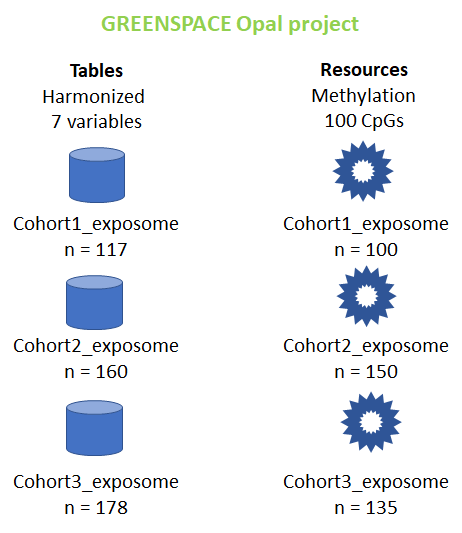

Figure 6: GREENSPACE project available data

The variables we have are:

- **CODE**: id number that links to the sample names in the `ExposomeSet`
- **Green access** (greenyn300_0): Is there a green space of >5,000 m2 in a distance of 300 m, at birth? [binary, 0=no; 1=yes]
- **Green access** (greenyn300_s): Is there a green space of >5,000 m2 in a distance of 300 m, at school? [binary, 0=no; 1=yes]
- **Green access** (greenyn300_4): Is there a green space of >5,000 m2 in a distance of 300 m, at 4y? [binary, 0=no; 1=yes]
- **Greeness** (ndvi100_0): Average of normalized difference vegetation index (NDVI) within a buffer of 100 m, at birth [continuous, in ndvi value]
- **Greeness** (ndvi100_s): Average of normalized difference vegetation index (NDVI) within a buffer of 100 m, at school [continuous, in ndvi value]
- **Greeness** (ndvi100_4): Average of normalized difference vegetation index (NDVI) within a buffer of 100 m, at 4y [continuous, in ndvi value]

So, the requirements to perform such analyses are:

1. To install `dsBaseClient` and `dsOmicsClient` R packages into analyst computer.
2. To have harmonized exposome data in a opal server for each cohort (already done in LifeCycle) (**Tables**).
3. To have a resource with an `ExpressioSet` encapsulating methylation data for each cohort (**Resources**) [see [here](https://rpubs.com/jrgonzalezISGlobal/tutorial_resources) for a description of an `ExpressionSet` and how to deal with it as a resource]
   - WP4 is providing an R code to create such `ExpressionSet`
   - Each cohort will provide the URL having an `.Rdata` file with the required object.
4. [To install required DataSHIELD packages into the Opal server](https://isglobal-brge.github.io/resource_bookdown/tips-and-tricks.html#how-to-install-datashield-packages-into-opal-server): `dsOmics`, `dsBase` and `resourcer`

For this tutorial, we have tried to mimic real situations we have a project called `GREENSPACE` in our Opal demo server having exposome data for 3 cohorts (simulated data).

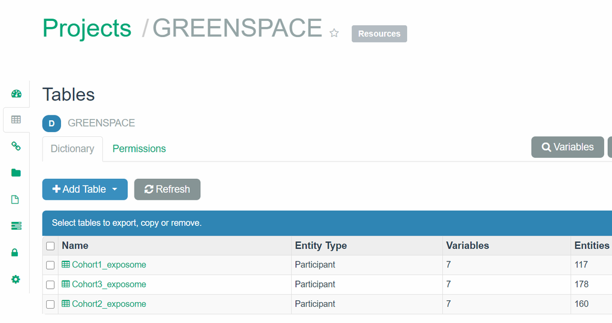

Figure 7: Tables available in the project GREENSPACE of Opal demo site

In the next figure we can see that there are 7 variables at each table and different number of samples (117, 178, 160). Using what you have learn in the DataSHIELD beginners course, you can obtain this information from the client site.

We start by creating the connection to our server and assigning the tables to an R object called `exposome`:

```r
library(DSOpal)
library(dsBaseClient)


builder <- newDSLoginBuilder()
builder$append(server = 'study1', url = 'https://opal-demo.obiba.org',
               user = 'dsuser', password = 'password')
builder$append(server = 'study2', url = 'https://opal-demo.obiba.org',
               user = 'dsuser', password = 'password')
builder$append(server = 'study3', url = 'https://opal-demo.obiba.org',
               user = 'dsuser', password = 'password')



logindata <- builder$build()
conns <- datashield.login(logins = logindata)

datashield.assign.table(conns, symbol = "exposome",
                        table = list(study1 = "GREENSPACE.Cohort1_exposome",
                                     study2 = "GREENSPACE.Cohort2_exposome",
                                     study3 = "GREENSPACE.Cohort3_exposome"))
```

The we can run basic DataSHIELD commands

```r
ds.class('exposome')
```

```
$study1
[1] "data.frame"

$study2
[1] "data.frame"

$study3
[1] "data.frame"
```

```r
ds.dim('exposome')
```

```
$`dimensions of exposome in study1`
[1] 117   7

$`dimensions of exposome in study2`
[1] 160   7

$`dimensions of exposome in study3`
[1] 178   7

$`dimensions of exposome in combined studies`
[1] 455   7
```

```r
ds.colnames('exposome')
```

```
$study1
[1] "CODE"         "greenyn300_0" "greenyn300_s" "greenyn300_4" "ndvi100_0"    "ndvi100_s"
[7] "ndvi100_4"

$study2
[1] "CODE"         "greenyn300_0" "greenyn300_s" "greenyn300_4" "ndvi100_0"    "ndvi100_s"
[7] "ndvi100_4"

$study3
[1] "CODE"         "greenyn300_0" "greenyn300_s" "greenyn300_4" "ndvi100_0"    "ndvi100_s"
[7] "ndvi100_4"
```

The three `.Rdata` file containing the different `ExpressionSet`s are available at:

- https://github.com/isglobal-brge/brgedata/blob/master/data/Cohort1_Methyl_C_blood_0y_450K.Rdata?raw=true
- https://github.com/isglobal-brge/brgedata/blob/master/data/Cohort2_Methyl_C_blood_0y_450K.Rdata?raw=true
- https://github.com/isglobal-brge/brgedata/blob/master/data/Cohort3_Methyl_C_blood_0y_450K.Rdata?raw=true

So, we need to create the resources into the Opal server as we leant in the section 3.3 of the [resources workshop](https://rpubs.com/jrgonzalezISGlobal/tutorial_resources). Our GREENSPACE project already have those resources created:

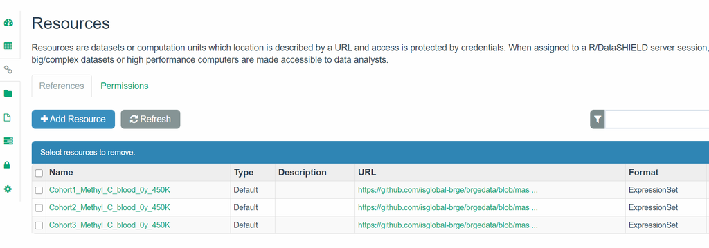

Figure 8: Resources available in the project GREENSPACE of Opal demo site

Then, we can load those resources into our DataSHIELD session as an R object called `methy` which is an object of class `ExpressionSet` by:

```r
datashield.assign.resource(conns, symbol = "eSet",
                           resource = list(study1 = "GREENSPACE.Cohort1_Methyl_C_blood_0y_450K",
                                           study2 = "GREENSPACE.Cohort2_Methyl_C_blood_0y_450K",
                                           study3 = "GREENSPACE.Cohort3_Methyl_C_blood_0y_450K"))

datashield.assign.expr(conns, symbol = "methy", expr = quote(as.resource.object(eSet)))
```

Then, using `dsOmicsClient` library we can first check that our methylation data have properly been integrated into the DataSHIELD R server

```r
library(dsOmicsClient)
ds.class('methy')
```

```
$study1
[1] "ExpressionSet"
attr(,"package")
[1] "Biobase"

$study2
[1] "ExpressionSet"
attr(,"package")
[1] "Biobase"

$study3
[1] "ExpressionSet"
attr(,"package")
[1] "Biobase"
```

```r
ds.nFeatures('methy')
```

```
$study1
Features
     100

$study2
Features
     100

$study3
Features
     100

attr(,"class")
[1] "dsnFeatures" "list"
```

```r
ds.nSamples('methy')
```

```
$study1
Samples
    100

$study2
Samples
    150

$study3
Samples
    135

attr(,"class")
[1] "dsnSamples" "list"
```

Then, in order to be able to use `ds.limma ()` we need first to add the exposome data to the `ExpressionSet` object. To this end, the function `ds.addPhenoData ()` has been created

```r
ds.addPhenoData('methy', 'exposome', identifier = "CODE", name = 'methy2')
```

This function creates a new object in the R server side that is called `methy2`

```r
ds.ls()
```

```
$study1
$study1$environment.searched
[1] "R_GlobalEnv"

$study1$objects.found
[1] "eSet"     "exposome" "methy"    "methy2"


$study2
$study2$environment.searched
[1] "R_GlobalEnv"

$study2$objects.found
[1] "eSet"     "exposome" "methy"    "methy2"


$study3
$study3$environment.searched
[1] "R_GlobalEnv"

$study3$objects.found
[1] "eSet"     "exposome" "methy"    "methy2"
```

This is an object of class `ExpressionSet`

```r
ds.class('methy2')
```

```
$study1
[1] "ExpressionSet"
attr(,"package")
[1] "Biobase"

$study2
[1] "ExpressionSet"
attr(,"package")
[1] "Biobase"

$study3
[1] "ExpressionSet"
attr(,"package")
[1] "Biobase"
```

Having the exposures in the phenotypic data

```r
ds.fvarLabels('methy')
```

```
$study1
 [1] "X"          "id_methyl"  "id"         "age_methyl" "sex_methyl" "anc_methyl" "cohort"
 [8] "Bcell"      "CD4T"       "CD8T"       "Gran"       "Mono"       "NK"         "nRBC"

$study2
 [1] "X"          "id_methyl"  "id"         "age_methyl" "sex_methyl" "anc_methyl" "cohort"
 [8] "Bcell"      "CD4T"       "CD8T"       "Gran"       "Mono"       "NK"         "nRBC"

$study3
 [1] "X"          "id_methyl"  "id"         "age_methyl" "sex_methyl" "anc_methyl" "cohort"
 [8] "Bcell"      "CD4T"       "CD8T"       "Gran"       "Mono"       "NK"         "nRBC"

attr(,"class")
[1] "dsfvarLabels" "list"
```

```r
ds.fvarLabels('methy2')
```

```
$study1
 [1] "X"            "id_methyl"    "id"           "age_methyl"   "sex_methyl"   "anc_methyl"
 [7] "cohort"       "Bcell"        "CD4T"         "CD8T"         "Gran"         "Mono"
[13] "NK"           "nRBC"         "greenyn300_0" "greenyn300_s" "greenyn300_4" "ndvi100_0"
[19] "ndvi100_s"    "ndvi100_4"

$study2
 [1] "X"            "id_methyl"    "id"           "age_methyl"   "sex_methyl"   "anc_methyl"
 [7] "cohort"       "Bcell"        "CD4T"         "CD8T"         "Gran"         "Mono"
[13] "NK"           "nRBC"         "greenyn300_0" "greenyn300_s" "greenyn300_4" "ndvi100_0"
[19] "ndvi100_s"    "ndvi100_4"

$study3
 [1] "X"            "id_methyl"    "id"           "age_methyl"   "sex_methyl"   "anc_methyl"
 [7] "cohort"       "Bcell"        "CD4T"         "CD8T"         "Gran"         "Mono"
[13] "NK"           "nRBC"         "greenyn300_0" "greenyn300_s" "greenyn300_4" "ndvi100_0"
[19] "ndvi100_s"    "ndvi100_4"

attr(,"class")
[1] "dsfvarLabels" "list"
```

we can verify that matching has properly been performed

```r
ds.nSamples('methy2')
```

```
$study1
Samples
     97

$study2
Samples
    145

$study3
Samples
    133

attr(,"class")
[1] "dsnSamples" "list"
```

Now, we are ready to perform the required EXWAS by

```r
ewas <- ds.limma(model = ~ greenyn300_0,
                      Set = "methy2")
```

We can meta-analyze our results as we want, since we have the required information in our computer

```r
ewas
```

```
$study1
# A tibble: 100 x 10
   id            logFC      CI.L      CI.R AveExpr     t P.Value adj.P.Val     B      SE
   <chr>         <dbl>     <dbl>     <dbl>   <dbl> <dbl>   <dbl>     <dbl> <dbl>   <dbl>
 1 cg14008030  0.0288   0.00537   0.0523    0.526   2.44  0.0165     0.613 -4.66 0.0100
 2 cg23999112  0.0258   0.00428   0.0473    0.752   2.38  0.0193     0.613 -4.80 0.0118
 3 cg18762746  0.00589  0.000781  0.0110    0.967   2.29  0.0243     0.613 -5.00 0.00594
 4 cg05597748 -0.0195  -0.0365   -0.00257   0.813  -2.29  0.0245     0.613 -5.01 0.0170
 5 cg04496485 -0.00869 -0.0175    0.000171  0.0525 -1.95  0.0545     0.989 -5.70 0.00431
 6 cg12285627  0.0128  -0.00161   0.0272    0.615   1.76  0.0812     0.989 -6.03 0.0231
 7 cg01097950  0.0160  -0.00253   0.0345    0.814   1.71  0.0899     0.989 -6.11 0.0119
 8 cg08900511  0.0149  -0.00325   0.0330    0.845   1.63  0.107      0.989 -6.25 0.0142
 9 cg05475702 -0.0212  -0.0480    0.00557   0.703  -1.57  0.119      0.989 -6.34 0.0133
10 cg16736630 -0.0335  -0.0781    0.0112    0.501  -1.49  0.140      0.989 -6.47 0.0281
# ... with 90 more rows

$study2
# A tibble: 100 x 10
   id            logFC      CI.L    CI.R AveExpr     t P.Value adj.P.Val     B      SE
   <chr>         <dbl>     <dbl>   <dbl>   <dbl> <dbl>   <dbl>     <dbl> <dbl>   <dbl>
 1 cg14008030 0.0163    0.000457 0.0322   0.531   2.03  0.0438     0.989 -6.06 0.00660
 2 cg11422233 0.00539  -0.000365 0.0111   0.0830  1.85  0.0662     0.989 -6.41 0.00802
 3 cg05662829 0.0165   -0.00126  0.0342   0.815   1.84  0.0684     0.989 -6.44 0.00322
 4 cg06402284 0.00306  -0.000481 0.00660  0.0408  1.71  0.0897     0.989 -6.66 0.00993
 5 cg00381604 0.00282  -0.000583 0.00621  0.0306  1.64  0.104      0.989 -6.78 0.00172
 6 cg01551879 0.00129  -0.000291 0.00287  0.0181  1.61  0.109      0.989 -6.82 0.0147
 7 cg12045430 0.00492  -0.00144  0.0113   0.0361  1.53  0.129      0.989 -6.95 0.00723
 8 cg24699430 0.000768 -0.000275 0.00181  0.0145  1.46  0.148      0.989 -7.05 0.00878
 9 cg04407431 0.000908 -0.000327 0.00214  0.0173  1.45  0.148      0.989 -7.06 0.00859
10 cg08167039 0.00203  -0.000735 0.00479  0.0352  1.45  0.149      0.989 -7.06 0.0150
# ... with 90 more rows

$study3
# A tibble: 100 x 10
   id            logFC      CI.L      CI.R AveExpr     t P.Value adj.P.Val     B      SE
   <chr>         <dbl>     <dbl>     <dbl>   <dbl> <dbl>   <dbl>     <dbl> <dbl>   <dbl>
 1 cg09989996  0.00735  0.00288   0.0118    0.950   3.25 0.00146     0.146 -2.75 0.00815
 2 cg13938959 -0.0254  -0.0423   -0.00853   0.731  -2.98 0.00347     0.173 -3.54 0.00907
 3 cg10988531  0.0193   0.00539   0.0331    0.834   2.75 0.00686     0.229 -4.17 0.00818
 4 cg14057946  0.0114   0.00225   0.0206    0.0945  2.46 0.0151      0.377 -4.87 0.0121
 5 cg03213877 -0.00174 -0.00333  -0.000160  0.0174 -2.18 0.0312      0.624 -5.51 0.00536
 6 cg01068023 -0.00801 -0.0156   -0.000416  0.888  -2.09 0.0388      0.647 -5.70 0.0186
 7 cg21996134  0.00995 -0.000355  0.0203    0.954   1.91 0.0583      0.790 -6.05 0.00899
 8 cg21870274 -0.0165  -0.0343    0.00127   0.814  -1.84 0.0685      0.790 -6.18 0.0105
 9 cg11954957  0.0272  -0.00282   0.0573    0.746   1.79 0.0753      0.790 -6.26 0.0130
10 cg18263059  0.0107  -0.00125   0.0226    0.0381  1.77 0.0790      0.790 -6.30 0.0169
# ... with 90 more rows

attr(,"class")
[1] "dsLimma" "list"
```

We have implemented a very simple function that makes use of [metap](https://cran.r-project.org/web/packages/metap/vignettes/compare.pdf) package to combine p-values from microarray experiments. For both ATHELETE and LifeCycle researchers we highly recommend to use our [EASIER](https://github.com/isglobal-brge/EASIER/blob/main/vignettes/EASIER.pdf) package

```r
metaPvalues(ewas)
```

```
# A tibble: 100 x 5
   id         study1 study2  study3 p.meta
   <chr>       <dbl>  <dbl>   <dbl>  <dbl>
 1 cg14008030 0.0165 0.0438 0.795   0.0209
 2 cg14057946 0.263  0.213  0.0151  0.0280
 3 cg09989996 0.976  0.955  0.00146 0.0401
 4 cg23999112 0.0193 0.771  0.102   0.0433
 5 cg13938959 0.967  0.829  0.00347 0.0672
 6 cg05597748 0.0245 0.353  0.334   0.0691
 7 cg16047670 0.158  0.182  0.105   0.0713
 8 cg10988531 0.935  0.544  0.00686 0.0791
 9 cg18762746 0.0243 0.402  0.463   0.0949
10 cg01068023 0.693  0.255  0.0388  0.126
# ... with 90 more rows
```

We can also run analyses adjusted for other covariates or even for cell types if metadata is available in the `ExpressionSet`

```r
ds.fvarLabels('methy2')
```

```
$study1
 [1] "X"            "id_methyl"    "id"           "age_methyl"   "sex_methyl"   "anc_methyl"
 [7] "cohort"       "Bcell"        "CD4T"         "CD8T"         "Gran"         "Mono"
[13] "NK"           "nRBC"         "greenyn300_0" "greenyn300_s" "greenyn300_4" "ndvi100_0"
[19] "ndvi100_s"    "ndvi100_4"

$study2
 [1] "X"            "id_methyl"    "id"           "age_methyl"   "sex_methyl"   "anc_methyl"
 [7] "cohort"       "Bcell"        "CD4T"         "CD8T"         "Gran"         "Mono"
[13] "NK"           "nRBC"         "greenyn300_0" "greenyn300_s" "greenyn300_4" "ndvi100_0"
[19] "ndvi100_s"    "ndvi100_4"

$study3
 [1] "X"            "id_methyl"    "id"           "age_methyl"   "sex_methyl"   "anc_methyl"
 [7] "cohort"       "Bcell"        "CD4T"         "CD8T"         "Gran"         "Mono"
[13] "NK"           "nRBC"         "greenyn300_0" "greenyn300_s" "greenyn300_4" "ndvi100_0"
[19] "ndvi100_s"    "ndvi100_4"

attr(,"class")
[1] "dsfvarLabels" "list"
```

For example, let us run the analysis adjusted for gender

```r
ewas.adj <- ds.limma(model = ~ greenyn300_0 + sex_methyl, Set = "methy2")
metaPvalues(ewas.adj)
```

```
# A tibble: 100 x 5
   id         study1 study2  study3 p.meta
   <chr>       <dbl>  <dbl>   <dbl>  <dbl>
 1 cg14008030 0.0230 0.0463 0.824   0.0288
 2 cg14057946 0.261  0.242  0.0145  0.0297
 3 cg09989996 0.990  0.945  0.00153 0.0415
 4 cg23999112 0.0214 0.785  0.111   0.0503
 5 cg05597748 0.0270 0.344  0.290   0.0658
 6 cg13938959 0.942  0.817  0.00373 0.0689
 7 cg10988531 0.959  0.550  0.00558 0.0701
 8 cg16047670 0.156  0.184  0.104   0.0707
 9 cg18762746 0.0293 0.395  0.476   0.109
10 cg01068023 0.665  0.275  0.0371  0.125
# ... with 90 more rows
```

Do not forget to logout the connection

```r
datashield.logout(conns)
```

## 4.1 Exercise 2

> Peform an EWAS using the same data that is available in the GREENSPACE project to determine which CpGs are differentially methylated for the exposures: `greenyn300_4`, `ndvi100_0` and `ndvi100_4`.

> EWAS requires to adjust the analyses for [cell type composition](https://www.futuremedicine.com/doi/full/10.2217/epi-2016-0153). The `ExpressionSet` contains the variables Bcell, CD4T, CD8T, Gran, Mono and NK in the sample metadata. Re-run the models adjustin for those variables